# Regresión lineal múltiple

Comparamos:

### Regresión lineal simple (una variable independiente o regresora)

$$ y = \beta_{0} + \beta_{1}x+\varepsilon $$

### Regresión lineal múltiple ($n$ variables independientes o regresoras)

$$ y = \beta_{0} + \beta_{1}x_{1}+ \beta_{2}x_{2}+\cdots+ \beta_{n}x_{n}+\varepsilon $$

La implementación de una regresión lineal múltiple es muy sencilla:

```r
df <- iris
head(df)
```

A data.frame: 6 × 5

|  | Sepal.Length <dbl> | Sepal.Width <dbl> | Petal.Length <dbl> | Petal.Width <dbl> | Species <fct> |
| --- | --- | --- | --- | --- | --- |
| 1 | 5.1 | 3.5 | 1.4 | 0.2 | setosa |
| 2 | 4.9 | 3.0 | 1.4 | 0.2 | setosa |
| 3 | 4.7 | 3.2 | 1.3 | 0.2 | setosa |
| 4 | 4.6 | 3.1 | 1.5 | 0.2 | setosa |
| 5 | 5.0 | 3.6 | 1.4 | 0.2 | setosa |
| 6 | 5.4 | 3.9 | 1.7 | 0.4 | setosa |

```r
# Definimos las variables

# Variables regresoras
x1 <- df$Sepal.Length
x2 <- df$Sepal.Width
x3 <- df$Petal.Width

# Variable objetivo
y <- df$Petal.Length

# implementacion
fit <- lm(y ~ x1 + x2 + x3)
summary(fit)
```

```
Call:
lm(formula = y ~ x1 + x2 + x3)

Residuals:
     Min       1Q   Median       3Q      Max
-0.99333 -0.17656 -0.01004  0.18558  1.06909

Coefficients:
            Estimate Std. Error t value Pr(>|t|)
(Intercept) -0.26271    0.29741  -0.883    0.379
x1           0.72914    0.05832  12.502   <2e-16 ***
x2          -0.64601    0.06850  -9.431   <2e-16 ***
x3           1.44679    0.06761  21.399   <2e-16 ***
---
Signif. codes:  0 ‘***’ 0.001 ‘**’ 0.01 ‘*’ 0.05 ‘.’ 0.1 ‘ ’ 1

Residual standard error: 0.319 on 146 degrees of freedom
Multiple R-squared:  0.968,	Adjusted R-squared:  0.9674
F-statistic:  1473 on 3 and 146 DF,  p-value: < 2.2e-16
```

# Análisis de supuestos sobre una regresión lineal simple

```r
# Variable regresora
x <- df$Petal.Width

# Variable objetivo
y <- df$Petal.Length

# implementacion
fit <- lm(y ~ x)
summary(fit)
```

```
Call:
lm(formula = y ~ x)

Residuals:
     Min       1Q   Median       3Q      Max
-1.33542 -0.30347 -0.02955  0.25776  1.39453

Coefficients:
            Estimate Std. Error t value Pr(>|t|)
(Intercept)  1.08356    0.07297   14.85   <2e-16 ***
x            2.22994    0.05140   43.39   <2e-16 ***
---
Signif. codes:  0 ‘***’ 0.001 ‘**’ 0.01 ‘*’ 0.05 ‘.’ 0.1 ‘ ’ 1

Residual standard error: 0.4782 on 148 degrees of freedom
Multiple R-squared:  0.9271,	Adjusted R-squared:  0.9266
F-statistic:  1882 on 1 and 148 DF,  p-value: < 2.2e-16
```

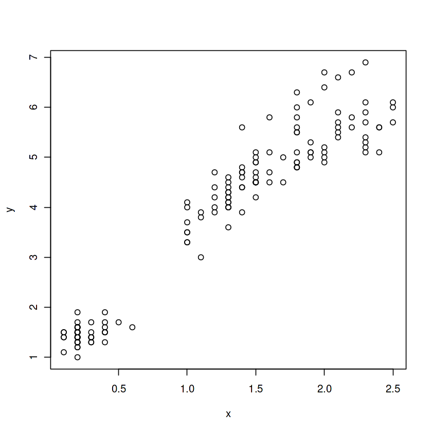

```r
plot(x=x, y=y)
```

1. Homocedasticidad: Emplearemos la prueba de hipótesis Breuch-Pagan
- $H_{0}$: varianza constante (homocedasticidad) vs
- $H_{1}$: no hay varianza constante.

Buscamos no rechazar ($p-value>\alpha$).

- p-value > 0.05: nos quedamos quedamos con $H_{0}$
- p-value < 0.05: nos quedamos quedamos con $H_{1}$

```r
# Librería necesaria
library(lmtest)

# bptest(fit): breush-pagan
bptest(fit)
```

```
	studentized Breusch-Pagan test

data:  fit
BP = 23.897, df = 1, p-value = 1.016e-06
```

dado que

$$ p-value = 1.016e-06 = 0.000001016<\alpha = 0.05 $$$$ 1.016e-06=1.016x10^{-6} $$

entonces se rechaza $H_{0}$, es decir, se rechaza la homocedasticidad por lo cual este supuesto no se está cumpliendo.

1. Linealidad: las variables interactúan mediante una relación lineal.

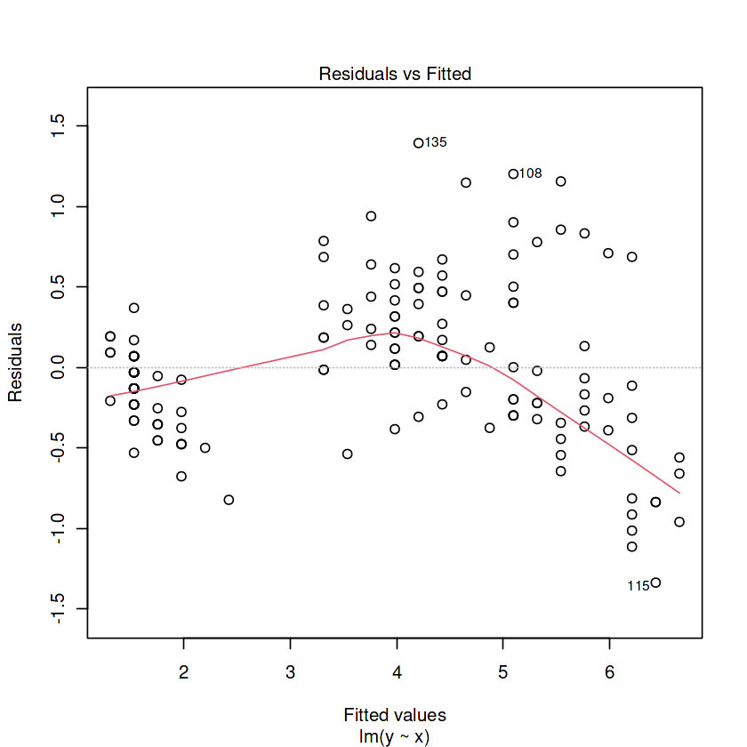

```r
# buscamos que la recta roja sea lo mas parecida a
# la recta horizontal
plot(fit, 1)
```

El supuesto de la linealidad tampoco se está cumpliendo

1. Los errores (valor predicho - valor real) se distribuyen *normal*. Para comprobar empleamos la prueba de hipótesis Shapiro-Wilk. Buscamos no rechazar $H_{0}$ (los errores se distribuyen normal).

p-value > 0.05: nos quedamos con $H_{0}$

```r
# Utilizamos la librería broom para calcular los errores de forma automática
library(broom)

# Guardamos los errores en columnas de nuestro dataframe de los datos
Datosfit <- augment(fit)

shapiro.test(Datosfit$.std.resid)
```

```
	Shapiro-Wilk normality test

data:  Datosfit$.std.resid
W = 0.99019, p-value = 0.3823
```

Este supuesto sí se está cumpliendo

1. Las observaciones son independientes entre sí. Para ello emplearemos la prueba de Durbin-Watson donde buscamos no rechazar $H_{0}$ (las observaciones son independientes entre sí)

p-value > 0.05: nos quedamos con $H_{0}$

```r
#Prueba para autocorrelación de orden 1

dwtest(fit)
```

```
	Durbin-Watson test

data:  fit
DW = 1.4296, p-value = 0.0001623
alternative hypothesis: true autocorrelation is greater than 0
```

p -value < 0.05: nos quedamos con $H_{1}$

```r
library(randtests)
runs.test(Datosfit$.std.resid)
```

```
	Runs Test

data:  Datosfit$.std.resid
statistic = -3.7664, runs = 50, n1 = 74, n2 = 69, n = 143, p-value =
0.0001656
alternative hypothesis: nonrandomness
```

```
	Runs Test - Two sided

data:  Datosfit$.std.resid
Standardized Runs Statistic = -4.2601, p-value = 2.043e-05
```

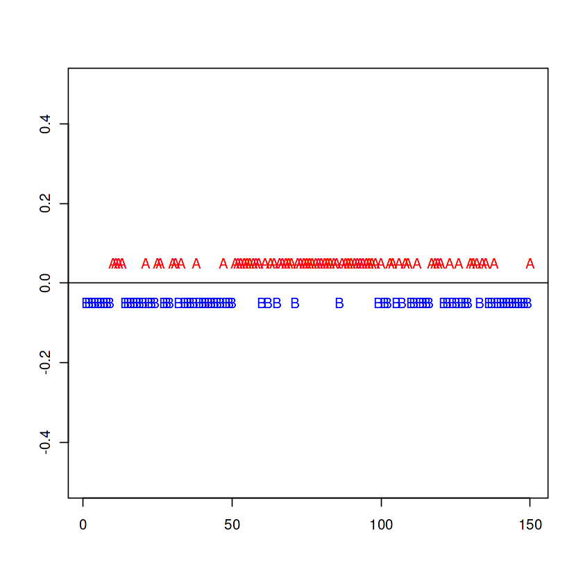

```r
#Prueba de rachas
library(lawstat)
runs.test(Datosfit$.std.resid, plot.it = TRUE)
```

Este supuesto tampoco se cumple.